# [Financial Evaluation and Strategy: Corporate Finance](https://www.coursera.org/learn/corporate-finance/home/welcome) : *Module 4*

[Improving Business Finances and Operations Specialization](https://www.coursera.org/specializations/business-operations) by University of Illinois at Urbana-Champaign

[®γσ, Eng Lian Hu](http://englianhu.wordpress.com) 白戸則道®

2016-08-02

# 1. Introduction

- Section 1.1 Overview
- Section 1.2 Instructions
- Section 1.3 Review criteria
- Section 1.4 Reminders

## 1.1 Overview

**Instructions**

The purpose of this assignment is to give you the opportunity to apply the concepts you have learned in this module and to discuss some of the key ideas of the module in your own words. Follow the instructions provided and respond to each question. This a required activity for this module. The activity is peer reviewed, so after you submit your responses, you will review submissions by fellow learners in the course.

## 1.2 Instructions

There are multiple steps to this assignment.

First, you will submit your answers to each questions based on the information in the Assignment Details section. Enter your answers directly in the spaces provided in the **My submission tab**. You may save a draft of your work as you go, and you can come back later to continue working on your draft. When you are finished working, click the **Preview** button, verify your identity, and then Submit the assignment. Please answer each question fully and concisely.

Then, you will evaluate the submissions of **at least THREE** of your peers based on the instructions provided. You may begin giving feedback to other students as soon as you submit your assignment, click the **Review peers** tab to begin. Feel free to provide additional reviews beyond the three required!

**Assignment 4 is described in Video Lesson 4-14, you should watch this video before doing the assignment.**

[video not shown]

The discussion of the assignment solution is provided in Video Lesson 4-15. Do the assignment on your own first, **before** viewing the assignment discussion video! Please view the assignment discussion video **before** completing the review of your peers.

## 1.3 Review criteria

For Assignment #4, you will be responsible for evaluating the submissions of THREE of your peers. Before evaluating, please see the video I prepared with my discussion of the answers to [Assignment #4](https://www.coursera.org/learn/corporatefinance/lecture/F0ZHM/assignment-4-discussion).

Assignment #4 is worth 100 points total. Points are only given for correct/reasonable answers in the manner specified below, incorrect/unreasonable answers get zero points. Points should be allocated as follows:

### 1.3.1 Question 1

#### 1.3.1.1 Question 1-a

- **20 points** for a complete answer that is correct. To get 10 points the student should set up the cash flows correctly, and calculate the correct NPV of the synergies
- **15 points** for a good answer that has calculation mistakes. For example if the student sets up the right decision tree but makes a calculation mistake to get the NPV
- **10 points** for an incomplete answer

#### 1.3.1.2 Question 1-b

- **10 points** for a reasonable answer that is consistent with the analysis in part a)
- **5 points** for an incomplete answer

#### 1.3.1.3 Question 1-c

- **10 points** for a reasonable answer that is based in the mini-case data and the arguments in the lectures
- **5 points** for an incomplete answer

### 1.3.2 Question 2

- **10 points** for a reasonable answer that is based on the arguments that we discussed in the lectures
- **5 points** for an incomplete answer

### 1.3.3 Question 3

- **10 points** for a reasonable answer that is based on the arguments that we discussed in the lectures
- **5 points** for an incomplete answer

### 1.3.4 Question 4

- **20 points** for a reasonable answer that correctly discusses both whether the Beta is 1.1, and suggests a reasonable way of estimating the Beta
- **10 points** for an incomplete answer, for example if the suggestion to calculate Beta does not make sense

### 1.3.5 Question 5

- **10 points** for the correct calculation of the WACC
- **5 points** for an incomplete answer

### 1.3.6 Question 6

- **10 points** for a reasonable answer that is consistent with the analysis in question 5
- **5 points** for an incomplete answer or an answer that is too long (longer than 1 paragraph)

### 1.3.7 Question 7

- **10 points** for the correct calculation of the EVA
- **5 points** for an incomplete answer

### 1.3.8 Question 8

- **10 points** for a reasonable answer that is consistent with the analysis in question 7
- **5 points** for an incomplete answer or an answer that is too long (longer than 1 paragraph)

**Recommendations for Fair Peer Review:**

- For questions that require calculations only, the score should be based on whether or not the answer provided is correct.
- For subjective questions, the score should not be based on whether or not you agree with the answer, rather on whether the answer is complete and well-supported.
- Both content and organization are important components of a response. Good writing is confident and clearly focused with relevant details to enrich the content. Good writing also follows instructions, such as word limits, and offers requested information.
- A clear and concise answer is preferable to a long response that lacks coherence.Focus should be on content; try not to unduly penalize responses for spelling or grammar.

## 1.4 Reminders

### 1.4.1 Using the Forums

Your fellow students are a great resource, and we encourage you to sharpen your ideas against them in the forums. You can post your arguments in the Module 1 Forum and receive feedback before submitting this assignment. Additionally, make sure to pay attention to posts from the instructors, which are intended to spur conversation on topics related to the week’s theme.

### 1.4.2 Honor Code

Please remember that you have agreed to the Honor Code, and your submission should be entirely yours. Our definition of plagiarism follows from standard literature: passing off someone else’s work as your own, whether from your peers or Wikipedia. If you need to quote material, remember to cite your source, for example: “But, as expressed by Spinoza, all things excellent are as difficult as they are rare (Baruch Spinoza,”Ethica" source: thinkexist.com)."

# 2. Case Study

**Important Information**

It is especially important to submit this assignment before the deadline, August 7, 11:59 PM PDT, because it must be graded by others. If you submit late, there may not be enough classmates around to review your work. This makes it difficult - and in some cases, impossible - to produce a grade. Submit on time to avoid these risks.

## 2.1 Question 1

> On September 4th, 2009 (Friday), Cadbury’s shares closed trading at 5.71 pounds a share in London. The firm had 1.37 billion shares outstanding at that point. At current exchange rates, the market valuation of the firm in dollars was 12.83 billion dollars. On the weekend of September 4th to 7th (Monday was a holiday), Kraft announced a bid for all of Cadbury’s shares. The bid, which included both cash and shares, valued Cadbury at 7.45 pounds a share. The market responded enthusiastically to the bid, increasing Cadbury’s share price to 7.91 pounds at closing on September 8th, the first day of trading following the merger announcement.

> Kraft’s management was criticized for trying to buy Cadbury on the cheap. Kraft had closed trading on Sep 4th at 28.1 dollars a share, which was a full 9% below its 2001 IPO price. This lackluster stock price performance also suggested that the firm had struggled to create value from its string of acquisitions. The market was not kind to Kraft, whose shares traded at 26.45 dollars at close on Sep 8th. The firm had 1.48 billion shares outstanding.

> Kraft’s management justified the merger by arguing that it would produce 625 million dollars of annual cost savings, from operations, general and administrative expenses and marketing. These annual cost savings are expected to begin a year from now, and grow at 2% a year. Even after accounting for an after-tax integration cost of 1.2 billion, and taxes of 35%, these annual cost savings could easily justify the premium offered to Cadbury, according to Kraft’s managers (even without taking any potential revenue enhancements into account). Assume that the integration cost of 1.2 billion happens right when the merger is completed (one year before the annual cost savings begin).

> The food industry’s Beta is on the low side (close to 0.6), so Kraft’s cost of capital (its WACC) is not very high (around 8%).

### 2.1.1 Question 1-A

**Question**:

> Compute the value of the synergy as estimated by the management.

**Answer**:

Investors in a company that are aiming to take over another one must determine whether the purchase will be beneficial to them. In order to do so, they must ask themselves how much the company being acquired is really worth.

Naturally, both sides of an [M&A](http://www.investopedia.com/terms/m/mergersandacquisitions.asp) deal will have different ideas about the worth of a target company: its seller will tend to value the company at as high of a price as possible, while the buyer will try to get the lowest price that he can.

There are, however, many legitimate ways to value companies. The most common method is to look at comparable companies in an industry, but deal makers employ a variety of other methods and tools when assessing a [target company](http://www.investopedia.com/terms/t/targetfirm.asp). Here are just a few of them:

1. Comparative Ratios - The following are two examples of the many comparative metrics on which acquiring companies may base their offers:
   - [Price-Earnings Ratio (P/E Ratio)](http://www.investopedia.com/terms/p/price-earningsratio.asp) - With the use of this ratio, an acquiring company makes an offer that is a multiple of the earnings of the target company. Looking at the P/E for all the stocks within the same industry group will give the acquiring company good guidance for what the target’s P/E multiple should be.
   - [Enterprise-Value-to-Sales Ratio (EV/Sales)](http://www.investopedia.com/terms/e/enterprisevaluesales.asp) - With this ratio, the acquiring company makes an offer as a multiple of the revenues, again, while being aware of the [price-to-sales ratio](http://www.investopedia.com/terms/p/price-to-salesratio.asp) of other companies in the industry.
2. [Replacement Cost](http://www.investopedia.com/terms/r/replacementcost.asp) - In a few cases, acquisitions are based on the cost of replacing the target company. For simplicity’s sake, suppose the value of a company is simply the sum of all its equipment and staffing costs. The acquiring company can literally order the target to sell at that price, or it will create a competitor for the same cost. Naturally, it takes a long time to assemble good management, acquire property and get the right equipment. This method of establishing a price certainly wouldn’t make much sense in a service industry where the key assets - people and ideas - are hard to value and develop.
3. [Discounted Cash Flow (DCF)](http://www.investopedia.com/terms/d/dcf.asp) - A key valuation tool in M&A, discounted cash flow analysis determines a company’s current value according to its estimated future cash flows. Forecasted free cash flows (net income + depreciation/amortization - capital expenditures - change in working capital) are discounted to a present value using the company’s [weighted average costs of capital (WACC)](http://www.investopedia.com/terms/w/wacc.asp). Admittedly, DCF is tricky to get right, but few tools can rival this valuation method.

**Synergy: The Premium for Potential Success**

For the most part, acquiring companies nearly always pay a substantial premium on the stock market value of the companies they buy. The justification for doing so nearly always boils down to the notion of synergy; a merger benefits shareholders when a company’s post-merger share price increases by the value of potential synergy.

Let’s face it, it would be highly unlikely for rational owners to sell if they would benefit more by not selling. That means buyers will need to pay a premium if they hope to acquire the company, regardless of what pre-merger valuation tells them. For sellers, that premium represents their company’s future prospects. For buyers, the premium represents part of the post-merger synergy they expect can be achieved. The following equation offers a good way to think about synergy and how to determine whether a deal makes sense. The equation solves for the minimum required synergy:

$$\frac{premerge\ value\ of\ both\ companies + synergy}{post\ merged\ number\ of\ shares}-premerge\ stock\ price \cdots equation\ 2.1.1$$

Read more at [Mergers and Acquisitions: Valuation Matters](http://www.investopedia.com/university/mergers/mergers2.asp)

You can also refer to [How to calculate synergies in M&A](http://www.alphagamma.eu/finance/how-to-calculate-synergies-in-ma/) for further reference

[output not shown]

*table 2.1.1: Stock price statement of company Cadbury and Kraft in acquisation.*

| . | 2009 | 2010 | 2011 |
| --- | --- | --- | --- |
| Cost Savings |  | $625M |  |
| Taxes (35% of Cost Saving) |  | $218.75M |  |
| After-Tax Cash Flow |  | $406.25M | $414.38M |
| Integration Cost | -$1,200M |  |  |
| NPV Synergies | 5,570.83M |  |  |

*table 2.1.2: The synergy value of acquisation by Kraft.*

- $NPV_{Synergies}$ **of year 2009**: 406.25M ÷ (8% - 2%) - 1,200M = $5570.83M

  Kindly refer to reference 4th paper inside 4.4 References to know the formula about NPV
- **After-Tax Cash flow of year 2011** : $406.25M x 102% growth rates = $414.38M

You can refer to [Acquisition of Cadbury by Kraft Foods](https://en.wikipedia.org/wiki/Cadbury#Acquisition_by_Kraft_Foods) for more information.

Here are some relevant articles about acquisation: [The inside story of the Cadbury takeover](http://www.ft.com/cms/s/2/1e5450d2-2be5-11df-8033-00144feabdc0.html) and [Kraft buys Cadbury for £11.9bn: a Q&A](http://www.telegraph.co.uk/finance/newsbysector/retailandconsumer/7027042/Kraft-buys-Cadbury-for-11.9bn-a-QandA.html)

### 2.1.2 Question 1-B

**Question**:

> By refer to question 1, does the estimate of synergies in a) justify the premium that Kraft offered to Cadbury?

### 2.1.3 Question 1-C

**Question**:

> By refer to question 1, did the market agree with the management’s valuation of synergies? Discuss (2 paragraphs maximum)

**Answer**:

[output not shown]

**What are ‘Outstanding Shares’**

Outstanding shares refer to a company’s stock currently held by all its shareholders, including share blocks held by institutional investors and restricted shares owned by the company’s officers and insiders. Outstanding shares are shown on a company’s balance sheet under the heading “Capital Stock.” The number of outstanding shares is used in calculating key metrics such as a company’s market capitalization, as well as its [earnings per share (EPS)](http://www.investopedia.com/terms/e/eps.asp) and [cash flow per share (CFPS)](http://www.investopedia.com/terms/c/cashflowpershare.asp).

A company’s number of outstanding shares is not static, but may fluctuate widely over time. Also known as “shares outstanding.”

Read more: [Outstanding Shares Definition | Investopedia](http://www.investopedia.com/terms/o/outstandingshares.asp#ixzz4G01QVkhc)

## 2.2 Question 2

**Question**:

> Discuss the following statement: “US companies have a lot of excess cash on their balance sheets. Thus, we expect merger activity to increase (because firms must find ways to use their cash). In addition, these mergers (which should be mostly funded with cash holdings) are expected to be value-enhancing for acquirers.” (1 paragraph)

**Answer**:

```
  - A rich company might hold a lot of cash.
    * It can give dividends to shareholders.
    * Conduct acquisation activity to expend the business.
    * Invest in R&D to invent new products.
    * Invest on property assets.
  - However, above activities others than payback dividends to shareholders might need to do throughly study and research prior to spend the money.
```

## 2.3 Question 3

**Question**:

> A company with virtually no debt, stable cash flow, and moderate growth prospects has become the target for a private equity acquisition (LBO). The company’s CEO is concerned that an LBO may result in significant job losses, given the track record of this particular PE fund. Which advice would you give to the CEO? (1 paragraph)

**Answer**:

```
  - Normally, a private equity fund will looking for undervalued company for acquisation. They will restructure the company to create value and growth to make profit. Eventually will sell the company if there has other more profitable opportunity cost.
  - The CEO of company need to restucture the company, convince the shareholders, and also set a long term policy to growth the company. All action need to be taken before the company takeover by private equity fund which do preparation for bargain and dealing.
  - Since the company is undervalue, it means that the current CEO is a good leader which have a propective vision to growth the company in stable pace. Therefore the private equity fund might high probably keep employ who as CEO after acquisation.
```

**What is the difference between a hedge fund and a private equity fund?**

Although their investor profiles are often similar, there are significant differences between the aims and types of investments sought by hedge funds and private equity funds.

Both hedge funds and private equity funds appeal to high net worth individuals (many require minimum investments of $250,000 or more), traditionally are structured as limited partnerships and involve paying the managing partners basic management fees plus a percentage of profits.

Read more: [What is the difference between a hedge fund and a private equity fund? | Investopedia](http://www.investopedia.com/ask/answers/121614/what-difference-between-hedge-fund-and-private-equity-fund.asp#ixzz4G0BW1F2U)

## 2.4 Question 4

**Question**:

> Yahoo holds a large stake in Alibaba Group Holdings, a Chinese e-commerce company. The value of this stake has been estimated to be greater than 30 billion dollars. Yahoo’s market capitalization is approximately 35 billion dollars. According to Capital IQ, Yahoo’s Beta is 1.11. Would it be appropriate to use Yahoo’s Beta to compute the cost of capital for Yahoo? Why or why not? How would you estimate a WACC for Yahoo? (2 paragraphs)

**Answer**:

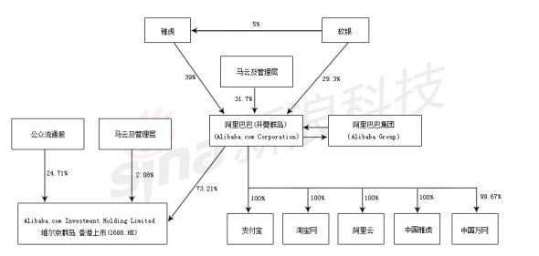

*figure 2.4.1: The business of Jack Ma*

You can refer to [Jack Ma: China’s Alibaba Wants to Acquire Yahoo](https://www.gsb.stanford.edu/insights/jack-ma-chinas-alibaba-wants-acquire-yahoo) for more details about the relationship between Yahoo and Alibaba.

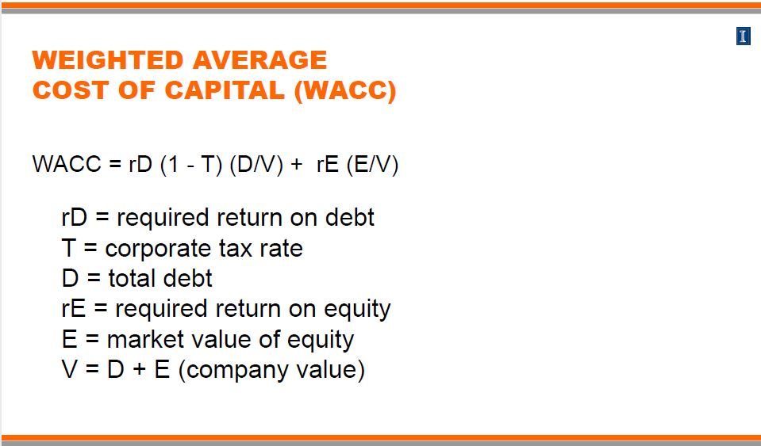

*equation 2.4.1: WACC.*

**What is ‘Weighted Average Cost Of Capital - WACC’**

Weighted average cost of capital (WACC) is a calculation of a firm’s cost of capital in which each category of capital is proportionately weighted.

Read more: [Weighted Average Cost Of Capital (WACC) Definition | Investopedia](http://www.investopedia.com/terms/w/wacc.asp#ixzz4G5y7NPb8)

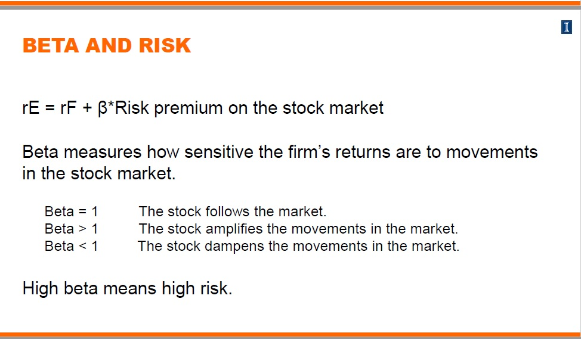

*equation 2.4.2: Beta and risk.*

## 2.5 Question 5

**Question**:

> The following data refers to Coca Cola (NYSE: KO)
> - Beta = 0.5
> - Required return on debt (yield to maturity on a long term bond) = 3.5%
> - Tax rate = 25%
> - Estimate the cost of capital (WACC) for Coca Cola.

**Answer**:

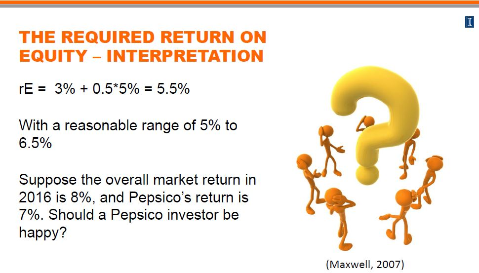

*equation 2.4.2: The required return on equity.*

## 2.6 Question 6

**Question**:

> How does Coca Cola’s WACC compare to Pepsico? Does this comparison make sense to you? (1 paragraph)

**Answer**:

```
  - Both companies are global recognizable public listed company in beverage industry. The WACC should be similar or no big difference.
```

## 2.7 Question 7

**Question**:

> Now consider Coca Cola’s income statement and balance sheet, and compute EVA in 2014 as we did for Pepsico.

**Answer**:

**What is ‘Economic Value Added - EVA’**

Economic value added (EVA) is a measure of a company’s financial performance based on the residual wealth calculated by deducting its cost of capital from its operating profit, adjusted for taxes on a cash basis. EVA can also be referred to as economic profit, and it attempts to capture the true economic profit of a company. This measure was devised by Stern Stewart and Co…

**Calculating EVA**

The formula for calculating EVA is: [Net Operating Profit After Taxes (NOPAT)](http://www.accountingtools.com/economic-value-added) - [Invested Capital * Weighted Average Cost of Capital (WACC)](http://www.investopedia.com/terms/c/costofcapital.asp)

Read more: [Economic Value Added (EVA) Definition | Investopedia](http://www.investopedia.com/terms/e/eva.asp#ixzz4GB02MFg2)

- By refer to [**PepsiCo, Inc.** *(NYSE:PEP)*](https://www.google.com/finance?q=NYSE%3APEP&fstype=ii&ei=NY-gV5CSFIrUugSE34rYCQ), we know the financial statement of the company.
- [PepsiCo Inc. (PEP)](https://www.stock-analysis-on.net/NYSE/Company/PepsiCo-Inc/DCF/Present-Value-of-FCFF) provides measurement of *Present Value of Free Cash Flow to the Firm (FCFF)* and also *Intrinsic Stock Value (Valuation Summary)*.
- [PepsiCo: Fundamental Analysis WACC, Cost of Debt and Cost of Equity $PEP](http://www.stockresearching.com/2014/02/17/pepsico-fundamental-analysis-wacc-cost-of-debt-and-cost-of-equity-pep/) has evaluate the counter and provide the calculation to get the WACC.
- From [Economic Profit](https://www.stock-analysis-on.net/NYSE/Company/PepsiCo-Inc/Performance-Measure/Economic-Value-Added#Economic-Profit), we get below figure:
  - Net operating profit after taxes (NOPAT) = $6,991
  - Cost of capital = 6.59%
  - Invested capital = $59,168
  - Then **Economic profit = NOPAT – Cost of capital × Invested capital = $6,991 – 6.59% × $59,168 = $3091.83**

## 2.8 Question 8

**Question**:

> How does Coca Cola’s EVA compare with Pepsico? Discuss. (1 paragraph)

**Answer**:

- [Coca-Cola: 2014 Fundamental Analysis WACC, Cost of Debt and Cost of Equity $KO](http://www.stockresearching.com/2014/05/15/coca-cola-2014-fundamental-analysis-wacc-cost-of-debt-and-cost-of-equity-ko/) has evaluate the counter and provide the calculation to get the WACC.
- Below website provides completed analysis on both counters.
  - [PepsiCo Inc. (PEP)](https://www.stock-analysis-on.net/NYSE/Company/PepsiCo-Inc)
  - [Coca-Cola Co. (KO)](https://www.stock-analysis-on.net/NYSE/Company/Coca-Cola-Co)
- By refer to [Coke Vs. Pepsi](http://www.123helpme.com/coke-vs-pepsi-view.asp?id=164243), we know the comparison between Coke and Pepsi.

[output not shown]

[output not shown]

# 3. Conclusion

You are feel free to refer to below answer video provided by lecturer. However there are quite some data and formlura are not completed.

[video not shown]

# 4. Appendices

- Section 4.1 Documenting File Creation
- Section 4.2 Versions’ Log
- Section 4.3 Speech and Blooper
- Section 4.4 References

## 4.1 Documenting File Creation

It’s useful to record some information about how your file was created.

- File creation date: 2016-07-31
- File latest updated date: 2016-08-02
- R version 3.3.1 (2016-06-21)
- R version (short form): 3.3.1
- [**rmarkdown** package](https://github.com/rstudio/rmarkdown) version: 1.0
- [**tufte** package](https://github.com/rstudio/tufte) version: 0.2
- File version: 1.0.0
- Author Profile: [®γσ, Eng Lian Hu](https://beta.rstudioconnect.com/englianhu/ryo-eng/)
- GitHub: [Source Code](https://github.com/englianhu/Coursera-Improving-Business-Finances-and-Operations/tree/master/4%20Financial%20Evaluation%20and%20Strategy%20-%20Corporate%20Finance)
- Additional session information:

[1] “2016-08-02 23:35:27 JST” setting value  
version R version 3.3.1 (2016-06-21) system x86_64, mingw32  
ui RTerm  
language (EN)  
collate English_United States.1252  
tz Asia/Tokyo  
date 2016-08-02  
sysname release version nodename “Windows” “10 x64” “build 10586” “RSTUDIO-SCIBROK” machine login user effective_user “x86-64” “scibr” “scibr” “scibr”

## 4.2 Versions’ Log

- *July 31, 2016*: [version: 1.0.0](https://github.com/englianhu/Coursera-Improving-Business-Finances-and-Operations/blob/master/4%20Financial%20Evaluation%20and%20Strategy%20-%20Corporate%20Finance/Module-04-Assignment.Rmd)

## 4.3 Speech and Blooper

I do appreciate that [University of Illinois at Urbana–Champaign](http://illinois.edu/) provides the [Improving Business Finances and Operations](https://www.coursera.org/specializations/business-operations) specialization via [Coursera](http://www.coursera.org). I used to study [Certified Accounting Technician (CAT)](http://www.accaglobal.com/ie/en/student/exam-support-resources/foundation-level-study-resources.html) course at [PAAC](http://www.paac.edu.my/index.php?p=location) more more decade. Now I need to review the finance and accounting course prior to conduct my research [Analyse the Finance and Stocks Price of Bookmakers](https://github.com/scibrokes/analyse-the-finance-and-stocks-price-of-bookmakers).

There are few books below that I need to read for further understanding.

- Managerial Accounting
- [**Financial Statement** A Step-by-Step Guide to Understanding and Creating Financial Reports *by Thomas R. Ittelson 2009*](https://github.com/scibrokes/analyse-the-finance-and-stocks-price-of-bookmakers/blob/master/data/finance.pdf)
- [**Corporate Finance (3rd Edition)** *by Ivo Welch 2014*](http://book.ivo-welch.info/ed3/)

Initially, I can get the data and all the figure of **PepsiCo**, but when I try to get the data of **Coca-cola**, the figure **suddenly** mosaicsed and paid account required.

- [PepsiCo Inc. (PEP)](https://www.stock-analysis-on.net/NYSE/Company/PepsiCo-Inc)
- [Coca-Cola Co. (KO)](https://www.stock-analysis-on.net/NYSE/Company/Coca-Cola-Co)

## 4.4 References

1. [**Corporate Finance (3rd Edition)** *by Ivo Welch 2014*](http://book.ivo-welch.info/ed3/)
2. [**Financial Evaluation and Strategy: Corporate Finance : Module 2** *by Ryo Eng Lian Hu 2016*](http://englianhu.github.io/2016/07/Financial%20Evaluation%20and%20Strategy%20-%20Corporate%20Finance/Module-02-Assignment.html), [**Alternative link**](http://rpubs.com/englianhu/198073)
3. [**Managerial Accounting: Tools for Facilitating and Guiding Business Decisions : Module 2 Mini-Project** *by Ryo Eng Lian Hu 2016*](http://englianhu.github.io/2016/07/Managerial%20Accounting%20-%20Tools%20for%20Facilitating%20and%20Guiding%20Business%20Decisions/Module-02-Assignment.html), [**Alternative link**](http://rpubs.com/englianhu/194583)
4. [**Financial Evaluation and Strategy: Corporate Finance : Module 2** *by Ryo Eng Lian Hu 2016*](http://rpubs.com/englianhu/199520), [**Alternative link**](http://englianhu.github.io/2016/07/Financial%20Evaluation%20and%20Strategy%20-%20Corporate%20Finance/Module-03-Assignment.html)